# ORF-level P-site quantification

Damon Hofman

January 23, 2023

# Introduction

In this notebook, I calculate the number of translated ORFs based on the calculation of P-site per million values (similar to TPM values). I defined translated ORFs as ORFs that have a P-sites per million (PPM) value of > 1 in at least 5 samples. PPM is calculated in the same way as TPM, using raw P site counts as input instead of raw read counts.

Input files:

- Sample metadata (Table S1A)
- Riboseq pipeline P site quantification output tables for canonical and non-canonical ORFs
- BED files containing all possible predicted P sites for canonical and non-canonical ORFs
- ORF reference table

# Pre-processing the P site counts table

```r
# Input file locations

# Canonical P-site counts matrix
MANE_mat_location <- "/hpc/pmc_vanheesch/projects/Damon/Medulloblastoma_analyses/01_processed_data/04_orf_quantification/quantification/Medullo_all_Psites_quant_MANE_new_allsamples/Medullo_all_Psites_quant_MANE_new_allsamples_psites.txt"
# Non-canonical P-site counts matrix
gencode_mat_location <- "/hpc/pmc_vanheesch/projects/Damon/Medulloblastoma_analyses/01_processed_data/04_orf_quantification/quantification/Medullo_all_Psites_quant_GENCODEp1_plus_ORFEOME_new_allsamples/Medullo_all_Psites_quant_GENCODEp1_plus_ORFEOME_new_allsamples_psites.txt"

# Metadata file
metadata_location <- "/hpc/pmc_vanheesch/projects/Damon/Medulloblastoma_analyses_final/01.26.2023_Table_S1.xlsx"

# ORF reference table
ref_table_location <- "/hpc/pmc_vanheesch/projects/Damon/Medulloblastoma_analyses_final/riboseq/P_sites_ref_table.csv"
```

```r
# Load metadata table S1A
sample_metadata <- readxl::read_xlsx(metadata_location,
  sheet = 1,
  col_names = T,
  skip = 2,
  .name_repair = "universal")
# Filter samples with both RNAseq and riboseq data
sample_metadata_complete <- sample_metadata[which(
  !is.na(sample_metadata$RNASeq_file_names) &
    !is.na(sample_metadata$RiboSeq_file_names..final.)), ]
```

```r
noncanonical_orf_data <- read.csv(noncanonical_orf_data_location, row.names = F)
```

```
Error in read.table(file = file, header = header, sep = sep, quote = quote,  :
  invalid 'row.names' specification
```

```r
# Load P sites data
MANE_mat <- read.table(MANE_mat_location, check.names = F)
gencode_mat <- read.table(gencode_mat_location, check.names = F)

# Combine P MANE and gencode P sites data
counts_psites <- data.frame(rbind(MANE_mat, gencode_mat), check.names = F)
# colnames(counts_psites)[which(colnames(counts_psites) == "S15_1824_S1_11_R1")] <- "S15_1824_JP10031_S11"

counts_psites <- counts_psites[, grep("HHT", colnames(counts_psites), invert = T)]  # Remove HHT samples

# Fix rownames
rownames(counts_psites) <- gsub("\\..{1,2}$","", rownames(counts_psites))  # Remove transcript version for MANE transcripts

# Give canonical ORFs (transcripts) "_CDS" suffix
# canonical_ind <- which(rownames(counts_psites) %in% subset(ref_table, ref_table$canonical == "Canonical")$tx_id)

canonical_ind <- which(!(rownames(counts_psites) %in% noncanonical_orf_data$orf_id))

rownames(counts_psites)[canonical_ind] <- paste0(rownames(counts_psites)[canonical_ind], "_CDS")
```

```r
# Match P-site counts columns to metadata rows

# Extract the column names from rna_counts that match the RNASeq_file_names in sample_metadata_celllines
match_counts <- unique(str_extract(sample_metadata_complete$RiboSeq_file_names..final., str_c(colnames(counts_psites), collapse = "|")))

# Subset rna_counts based on the matched columns
counts_psites <- counts_psites[, match_counts]

# Find matching metadata
metadata_matches <- grep(paste(match_counts, collapse = "|"), sample_metadata_complete$RiboSeq_file_names..final.)
sample_metadata_complete <- sample_metadata_complete[metadata_matches, ]

colnames(counts_psites) <- sample_metadata_complete$Sample_ID



# # Extract metadata and count names
# metadata_names <- sample_metadata_complete$RiboSeq_file_names..final.
# counts_names <- colnames(counts_psites)
#
# # Find indices for matching count names in metadata_names
# counts_ind <- sapply(counts_names, function(x) {
#   metadata_names[str_detect(pattern = x, string = metadata_names)]
# })
# counts_ind <- counts_ind[lengths(counts_ind) > 0]
#
# # Create a data frame with matched filenames and count names
# counts_ind_df <- data.frame(
#   ribo_filenames = as.character(counts_ind),
#   psite_counts_names = names(counts_ind)
# )
#
# # Make order of counts_ind match metadata table
# counts_ind_df <- counts_ind_df[match(metadata_names, counts_ind_df$ribo_filenames), ]
#
# # Select only columns from the counts file that match cell line metadata
# counts_psites <- counts_psites[, counts_ind_df$psite_counts_names]
#
# # Set colnames of rna_counts to match metadata sample IDs
# colnames(counts_psites) <- sample_metadata_complete$Sample_ID
```

```r
write.csv(counts_psites, "/hpc/pmc_vanheesch/projects/Damon/Medulloblastoma_analyses_final/riboseq/results/tables/S1_riboseq_P_sites_counts.csv", quote = F)
```

# Identification of translated ORFs

```r
# Load predicted P sites for each ORF or transcript to calculate ORF lengths
bed_canonical_p_all <- data.table::fread(
  "/hpc/pmc_vanheesch/projects/Damon/Medulloblastoma_analyses_final/riboseq/data/processed/psite_quantification/Medullo_all_Psites_quant_MANE/bedfiles/MANE.GRCh38.v1.0.ensembl_genomic.nochr.gtf_psites_p0.sorted.bed",
  col.names = c("chrom", "start", "end", "ref_id", "frame", "strand")) %>%
  subset(!grepl("pATG|pST", .$frame))
```

```
|--------------------------------------------------|
|==================================================|
```

## Selection of translation cutoff

```r
row_indices <- match(rownames(ORF_lengths), rownames(counts_psites))
# any(is.na(row_indices)) # FALSE; check if any rownames of ORF_lengths failed to map to rownames of counts_psites
ORF_lengths_match <- ORF_lengths[order(row_indices),]

all(rownames(ORF_lengths_match) == rownames(counts_psites))
```

```
[1] TRUE
```

```r
lengths_kb <- ORF_lengths_match$length_kb

rpk <- counts_psites / lengths_kb
pm_scalingfactors <- colSums(rpk)/1000000
ppm <- t(t(rpk) / pm_scalingfactors)
ppm_log2 <- log2(ppm + 0.01)

table(rowMeans(ppm) < 1)
```

```
FALSE  TRUE
20583  6545
```

```r
low_orfs <- rownames(ppm)[which(rowMeans(ppm) < 1)]
```

To select a cutoff, I plot the density of log2-transformed ppm values in each sample, and choose a cutoff between the low peak and the higher peak, which is around log2(ppm) = 0, or a ppm of 1.

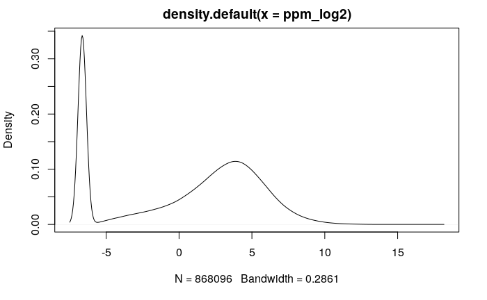

```r
dens = density(ppm_log2)
plot(dens)
```

```r
# threshold = identify(dens)
```

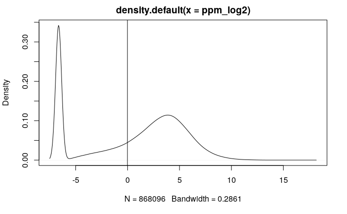

```r
cutoff = 0
threshold <- which(abs(dens$x-cutoff)==min(abs(dens$x-cutoff)))  # Find dens$x observation closest to
# threshold=120
plot(dens)
abline(v = dens$x[threshold])
```

## Calculating the total number translated ORFs

```r
mat_cutoff_extended <- mat_cutoff_summary %>%
  rownames_to_column("orf_id") %>%
  left_join(ref_table, by = "orf_id")  %>%
  left_join(noncanonical_orf_data, by = "orf_id")
```

```
Error in is.data.frame(y) : object 'ref_table' not found
```

## Calculating the number of translated canonical CDSs

```r
# Select canonical CDSs from logical cutoff table
mat_cutoff_canonical <- mat_cutoff[which(rownames(mat_cutoff) %in% rownames(subset(mat_cutoff_summary, canonical == "canonical"))), ]

# Calculate number and percentage of translated CDSs per samples
# orfs_per_sample_canonical <- data.frame(Sample_ID = colnames(mat_cutoff_canonical),
#                                         num_orfs = colSums(mat_cutoff_canonical)) %>%
#   mutate(perc_canonical = num_orfs / nrow(subset(ref_table, canonical == "Canonical"))) %>%
#   left_join(sample_metadata_complete)

orfs_per_sample_canonical <- data.frame(Sample_ID = colnames(mat_cutoff_canonical),
                                        num_orfs = colSums(mat_cutoff_canonical)) %>%
  left_join(sample_metadata_complete)
max(orfs_per_sample_canonical$num_orfs)
```

```
[1] 13868
```

```r
min(orfs_per_sample_canonical$num_orfs)
```

```
[1] 10712
```

```r
mean(orfs_per_sample_canonical$num_orfs)
```

```
[1] 12340.41
```

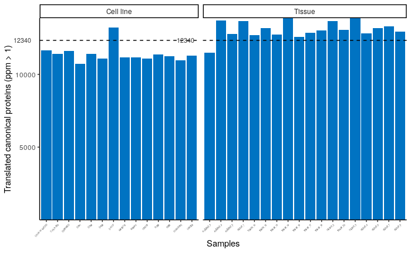

```r
# Plot with number of translated canonical CDSs per sample
orfs_per_sample_canonical[grep(pattern = "Tissue", x = orfs_per_sample_canonical$Sample_Type), ]$Sample_Type <- "Tissue"

ggplot(data = orfs_per_sample_canonical, aes(y = num_orfs, x = Sample_ID)) +
  geom_bar(stat = "identity", fill = colors[1]) +
  geom_hline(yintercept = mean(orfs_per_sample_canonical$num_orfs), linetype = 2) +
  geom_text(data = data.frame(Type = "Cell line"), aes(label = round(mean(orfs_per_sample_canonical$num_orfs))), x = -1, y = mean(orfs_per_sample_canonical$num_orfs),
            inherit.aes = FALSE, color = "grey20", hjust = .6, vjust = .5, size = 8 / .pt) +
  coord_cartesian(clip = "off", ylim = c(1, NA)) +
  scale_y_continuous(expand = c(0,0)) +
  labs(y = "Translated canonical proteins (ppm > 1)", x = "Samples") +
  facet_grid(~ Sample_Type, scales = "free_x", space = "free_x") +

  theme_classic() +
  theme(axis.text.x = element_text(angle = 45, hjust = 1, size = 3))


ggsave("/hpc/pmc_vanheesch/projects/Damon/Medulloblastoma_analyses_final/riboseq/results/plots/1C_num_translated_CDS.pdf",
       width = unit(4, "cm"),
       height = unit(4, "cm"))
```

# Normalized P site counts in all samples

First, I normalize all the ORF P site counts together using DESeq2.

```r
ORF_df <- data.frame(orf_id = ORFs_keep) %>%
  left_join(ORF_data) %>%
  mutate(orf_biotype = ifelse(is.na(.$orf_biotype), "Canonical", .$orf_biotype))
```

```
Error in is.data.frame(y) : object 'ORF_data' not found
```

```r
dds <- DESeq2::DESeqDataSetFromMatrix(countData = counts_psites, colData = coldata_select, design = ~ Sample_Type + MYC.group)
dds <- DESeq(dds)
```

[output not shown]

```r
vsd <- DESeq2::vst(dds, blind = F)

mat_dds <- data.frame(counts(dds, normalized = T))
mat_vsd <- assay(vsd)
```

Next, I select only the normalized counts for noncanonical ORF P sites.

```r
dds_NC <- dds[ORFs_keep, ]
dds_NC <- dds_NC[!grepl("_CDS", rownames(dds_NC)),]
vsd_NC <- vsd[rownames(dds_NC), ]
# mat_vsd_NC <- assay(vsd_NC)
mat_vsd_NC <- assay(vsd)[rownames(dds_NC), ]
```

## Heatmap of translated noncanonical ORFs

```r
# Get MYC expression levels
ind_MYC <- ref_table[grep("ENSG00000136997", ref_table$gene_id),]$orf_id
MYC_vsd <- as.numeric(mat_vsd[ind_MYC, ])
MYC_dds <- as.numeric(mat_dds[ind_MYC, ])

ind_MYCN <- ref_table[grep("ENSG00000134323", ref_table$gene_id),]$orf_id
MYCN_vsd <- as.numeric(mat_vsd[ind_MYCN, ])
MYCN_dds <- as.numeric(mat_dds[ind_MYCN, ])
```

```r
# Set heatmap colors
myCol <- colorRampPalette(rev(brewer.pal(n = 7, name = "RdYlBu")))(100)
myBreaks <- seq(0, 8, length.out = 100)
colors <- c("#0073C2FF", "#EFC000FF", "#868686FF", "#DC0000FF", "#7AA6DCFF", "#1B1B1BFF", "#FF7F0EFF", "#17BCEFFF", "#009E73", "#CC79A7")
```

```r
# Column annotation

# Make column annotation df
col_ann <- data.frame(
  Sample_Type = dds_NC$Sample_Type,
  # MYC_status = dds_NC$MYC_hi_lo,
  MYC_level = MYC_vsd,
  # MYCN_level = MYCN_vsd,
  row.names = colnames(assay(vsd_NC)))

col_ann$Sample_Type <- factor(col_ann$Sample_Type, levels = sort(unique(col_ann$Sample_Type)))
# col_ann$MYC_status <- factor(col_ann$MYC_status, levels = sort(unique(col_ann$MYC_status)))

# Set annotation colors
anno_cols <- list(
  Sample_Type = setNames(c(brewer.pal(3, "Pastel1")[1:length(unique(col_ann$Sample_Type))]),
                     c("Cell line", "Tissue")),
  # MYC_status = setNames(c(brewer.pal(length(unique(col_ann$MYC_status)), "Set1")[1:2]),
                                  # unique(col_ann$MYC_status)),
  MYC_level = colorRamp2(
    breaks = seq(min(MYC_vsd), max(MYC_vsd), length.out = 100),
    myCol)
  # MYCN_level = colorRamp2(
  #   breaks = seq(min(MYCN_vsd), max(MYCN_vsd), length.out = 100),
  #   myCol)
  )

# Make column HeatmapAnnotation
ha <- HeatmapAnnotation(
  df = col_ann,
  which = "column",
  col = anno_cols,
  show_annotation_name = F,
  simple_anno_size = unit(0.2, "cm"),
    annotation_legend_param = list(direction = "vertical", ncol = 2, labels_gp = gpar(fontsize = 6), title_gp = gpar(fontsize = 8, fontface = "bold")))
```

```r
# Row annotations

ref_table_NC <- ref_table[!grepl("_CDS", rownames(ref_table)),]

# Make row annotation df
df_row = data.frame(
  orf_id = rownames(mat_vsd_NC)) %>%
  left_join(ref_table_NC[,c("orf_id", "biotype")]) %>%
  column_to_rownames("orf_id")
ref_table_NC_summary <- ref_table_NC %>%
  group_by(biotype) %>%
  summarize(count = n())

df_row_summary <- df_row %>%
  group_by(biotype) %>%
  summarize(count = n()) %>%
  mutate(biotype_count = paste0(biotype, " (n = ", count, ")"))

df_row_2 <- rownames_to_column(df_row, "orf_id") %>%
  left_join(df_row_summary) %>%
  mutate(biotype = paste0(biotype, " (n = ", count, ")")) %>%
  column_to_rownames("orf_id") %>%
  select(biotype)
df_row_2$biotype <- factor(
  df_row_2$biotype,
  levels = c(df_row_summary[order(df_row_summary$count, decreasing = T), ]$biotype_count))



# Set row annotation colors
col_row <- list(
  biotype = setNames(colors[1:length(unique(df_row_2$biotype))],
                     unique(df_row_2$biotype)))
# Make row HeatmapAnnotation
row_ha = HeatmapAnnotation(
  which = "row",
  df = df_row_2,
  annotation_name_gp = gpar(fontsize = 6),
  show_annotation_name = F,
  col = col_row,
  show_legend = F)
```

```r
# Heatmap params
hm <- Heatmap(

  mat_vsd_NC,

  name = "DESeq2 norm. transformed counts",

  col = colorRamp2(myBreaks, myCol),

  # Parameters for expression color-bar legend
  heatmap_legend_param = list(
    color_bar = "continuous",
    title_position = "topcenter",
    legend_width = unit(4, "cm"),
    title_gp = gpar(fontsize = 8, fontface = "bold"),
    labels_gp = gpar(fontsize = 8),
    direction = "horizontal"),

  # Row parameters
  cluster_rows = T,
  show_row_names = F,
  row_names_gp = gpar(fontsize = 6),
  row_title_gp = gpar(fontsize = 6, fontface = "bold"),
  row_title_rot = T,
  show_row_dend = F,
  cluster_row_slices = F,
  row_split = df_row_2$biotype,


  # Column parameters
  column_split = factor(col_ann$Sample_Type, levels = unique(col_ann$Sample_Type)),
  show_column_names = F,
  show_column_dend = T,
  column_title_gp = gpar(fontsize = 8, fontface = "bold"),

  # Set column order
  cluster_columns = T,
  cluster_column_slices = T,

  # Column and row annotations
  top_annotation = ha,
  left_annotation = row_ha,
  use_raster = T
  # raster_resize_mat = TRUE
  )

# pdf("/hpc/pmc_vanheesch/projects/Damon/Medulloblastoma_analyses/02_results/figures/1E_MYClvls_new.pdf", width = 4, height = 4)
# ht <- draw(
#   hm,
#   heatmap_legend_side = "bottom",
#   annotation_legend_side = "right",
#   column_title_gp = gpar(fontsize = 16))
# dev.off()
```

## Average P sites per biotype

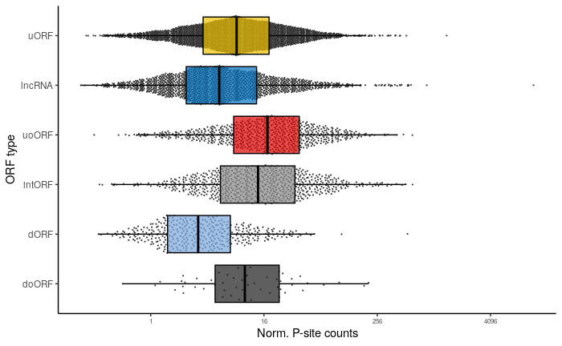